# NAFLD Transcriptomic Analysis

Nicolas Legrand

28 juin 2026

### 0.1 Bulk RNA‑seq differential expression across fibrosis stages

*Author: Nicolas Legrand — Date: 28 juin 2026*

Non‑alcoholic fatty liver disease (NAFLD) represents a progressive spectrum of liver disorders ranging from simple steatosis to non‑alcoholic steatohepatitis (NASH) and advanced fibrosis. Understanding the molecular mechanisms driving this progression is essential for identifying biomarkers and therapeutic targets.

This report presents a complete RNA‑seq analysis workflow applied to the GEO dataset **GSE135251**, which includes liver biopsy samples spanning multiple fibrosis stages. The analysis covers dataset retrieval, preprocessing, differential expression, visualization, and functional enrichment. The goal is to provide a clear, reproducible, and interpretable transcriptomic overview of NAFLD progression.

## 1 1. Dataset loading and initial exploration

This section retrieves the GEO dataset GSE135251 and performs an initial inspection of the expression matrix and sample metadata. The goal is to verify data integrity, sample count, and available annotations before processing.

```r
# ---- Setup ----
library(GEOquery)
library(tidyverse)

# ---- Download GEO dataset ----
gse <- getGEO("GSE135251", GSEMatrix = TRUE)

# Verify download
length(gse)
names(gse)

expr <- exprs(gse[[1]])
meta <- pData(gse[[1]])

dim(expr)
head(expr[,1:5])
head(meta)
```

```
## [1] 1
## [1] "GSE135251_series_matrix.txt.gz"
## [1]   0 216
##      GSM3998167 GSM3998168 GSM3998169 GSM3998170 GSM3998171
```

|  | title | geo_accession | status | submission_date | last_update_date | type | channel_count | source_name_ch1 | organism_ch1 | characteristics_ch1 | characteristics_ch1.1 | characteristics_ch1.2 | characteristics_ch1.3 | characteristics_ch1.4 | molecule_ch1 | extract_protocol_ch1 | extract_protocol_ch1.1 | taxid_ch1 | description | data_processing | data_processing.1 | data_processing.2 | data_processing.3 | data_processing.4 | platform_id | contact_name | contact_email | contact_institute | contact_address | … |
| --- | --- | --- | --- | --- | --- | --- | --- | --- | --- | --- | --- | --- | --- | --- | --- | --- | --- | --- | --- | --- | --- | --- | --- | --- | --- | --- | --- | --- | --- | --- |
| GSM3998167 | Liver patient 97 | GSM3998167 | Public on Dec 03 2020 | Aug 01 2019 | Apr 28 2021 | SRA | 1 | NAFLD_early_liver biopsy | Homo sapiens | nas score: 4 | fibrosis stage: 2 | group in paper: NASH_F2 | disease: NAFLD | Stage: early | total RNA | Frozen tissue samples were lysed using Trizol (Sigma-Aldrich) and mRNA was extracted with the Allprep DNA/RNA Micro kit (Qiagen). Concentrations and quality were assessed using the Agilent Pico 6000 k… | RNA libraries were prepared for sequencing using standard Illumina protocols | 9606 | 017-Ann-Daly_S1 | Reads were cropped to 75bp using Trimmomatic | Reads were mapped to GRCh38 (ensembl release 78) using STAR (v2.4.2a) | Gene count tables were produced using HTSeq-count (v0.11.2) with -r pos -s reverse | Genome_build: GRCh38, Ensembl release 78 | Supplementary_files_format_and_content: txt files with gene-level counts | GPL18573 | Simon,,Cockell | simon.cockell@newcastle.ac.uk | Newcastle University | Framlington Place | … |
| GSM3998168 | Liver patient 98 | GSM3998168 | Public on Dec 03 2020 | Aug 01 2019 | Apr 28 2021 | SRA | 1 | NAFLD_moderate_liver biopsy | Homo sapiens | nas score: 7 | fibrosis stage: 3 | group in paper: NASH_F3 | disease: NAFLD | Stage: moderate | total RNA | Frozen tissue samples were lysed using Trizol (Sigma-Aldrich) and mRNA was extracted with the Allprep DNA/RNA Micro kit (Qiagen). Concentrations and quality were assessed using the Agilent Pico 6000 k… | RNA libraries were prepared for sequencing using standard Illumina protocols | 9606 | 018-Ann-Daly_S2 | Reads were cropped to 75bp using Trimmomatic | Reads were mapped to GRCh38 (ensembl release 78) using STAR (v2.4.2a) | Gene count tables were produced using HTSeq-count (v0.11.2) with -r pos -s reverse | Genome_build: GRCh38, Ensembl release 78 | Supplementary_files_format_and_content: txt files with gene-level counts | GPL18573 | Simon,,Cockell | simon.cockell@newcastle.ac.uk | Newcastle University | Framlington Place | … |
| GSM3998169 | Liver patient 101 | GSM3998169 | Public on Dec 03 2020 | Aug 01 2019 | Apr 28 2021 | SRA | 1 | NAFLD_early_liver biopsy | Homo sapiens | nas score: 7 | fibrosis stage: 2 | group in paper: NASH_F2 | disease: NAFLD | Stage: early | total RNA | Frozen tissue samples were lysed using Trizol (Sigma-Aldrich) and mRNA was extracted with the Allprep DNA/RNA Micro kit (Qiagen). Concentrations and quality were assessed using the Agilent Pico 6000 k… | RNA libraries were prepared for sequencing using standard Illumina protocols | 9606 | 029-Ann-Daly_S4 | Reads were cropped to 75bp using Trimmomatic | Reads were mapped to GRCh38 (ensembl release 78) using STAR (v2.4.2a) | Gene count tables were produced using HTSeq-count (v0.11.2) with -r pos -s reverse | Genome_build: GRCh38, Ensembl release 78 | Supplementary_files_format_and_content: txt files with gene-level counts | GPL18573 | Simon,,Cockell | simon.cockell@newcastle.ac.uk | Newcastle University | Framlington Place | … |
| GSM3998170 | Liver patient 102 | GSM3998170 | Public on Dec 03 2020 | Aug 01 2019 | Apr 28 2021 | SRA | 1 | NAFLD_moderate_liver biopsy | Homo sapiens | nas score: 6 | fibrosis stage: 3 | group in paper: NASH_F3 | disease: NAFLD | Stage: moderate | total RNA | Frozen tissue samples were lysed using Trizol (Sigma-Aldrich) and mRNA was extracted with the Allprep DNA/RNA Micro kit (Qiagen). Concentrations and quality were assessed using the Agilent Pico 6000 k… | RNA libraries were prepared for sequencing using standard Illumina protocols | 9606 | 030-Ann-Daly_S5 | Reads were cropped to 75bp using Trimmomatic | Reads were mapped to GRCh38 (ensembl release 78) using STAR (v2.4.2a) | Gene count tables were produced using HTSeq-count (v0.11.2) with -r pos -s reverse | Genome_build: GRCh38, Ensembl release 78 | Supplementary_files_format_and_content: txt files with gene-level counts | GPL18573 | Simon,,Cockell | simon.cockell@newcastle.ac.uk | Newcastle University | Framlington Place | … |
| GSM3998171 | Liver patient 105 | GSM3998171 | Public on Dec 03 2020 | Aug 01 2019 | Apr 28 2021 | SRA | 1 | NAFLD_early_liver biopsy | Homo sapiens | nas score: 5 | fibrosis stage: 0 | group in paper: NASH_F0-F1 | disease: NAFLD | Stage: early | total RNA | Frozen tissue samples were lysed using Trizol (Sigma-Aldrich) and mRNA was extracted with the Allprep DNA/RNA Micro kit (Qiagen). Concentrations and quality were assessed using the Agilent Pico 6000 k… | RNA libraries were prepared for sequencing using standard Illumina protocols | 9606 | 031-Ann-Daly_S6 | Reads were cropped to 75bp using Trimmomatic | Reads were mapped to GRCh38 (ensembl release 78) using STAR (v2.4.2a) | Gene count tables were produced using HTSeq-count (v0.11.2) with -r pos -s reverse | Genome_build: GRCh38, Ensembl release 78 | Supplementary_files_format_and_content: txt files with gene-level counts | GPL18573 | Simon,,Cockell | simon.cockell@newcastle.ac.uk | Newcastle University | Framlington Place | … |
| GSM3998172 | Liver patient 106 | GSM3998172 | Public on Dec 03 2020 | Aug 01 2019 | Apr 28 2021 | SRA | 1 | NAFLD_early_liver biopsy | Homo sapiens | nas score: 5 | fibrosis stage: 1 | group in paper: NASH_F0-F1 | disease: NAFLD | Stage: early | total RNA | Frozen tissue samples were lysed using Trizol (Sigma-Aldrich) and mRNA was extracted with the Allprep DNA/RNA Micro kit (Qiagen). Concentrations and quality were assessed using the Agilent Pico 6000 k… | RNA libraries were prepared for sequencing using standard Illumina protocols | 9606 | 032-Ann-Daly_S7 | Reads were cropped to 75bp using Trimmomatic | Reads were mapped to GRCh38 (ensembl release 78) using STAR (v2.4.2a) | Gene count tables were produced using HTSeq-count (v0.11.2) with -r pos -s reverse | Genome_build: GRCh38, Ensembl release 78 | Supplementary_files_format_and_content: txt files with gene-level counts | GPL18573 | Simon,,Cockell | simon.cockell@newcastle.ac.uk | Newcastle University | Framlington Place | … |

## 3 3. Merge raw count files into a single count matrix

```r
# ---- merge_counts_fixed ----

library(tidyverse)

files <- list.files("GSE135251/raw", full.names = TRUE)

read_count_file <- function(f) {
  df <- read.delim(f, header = TRUE)

  gene_col <- grep("Geneid|gene|Gene|ID", colnames(df), ignore.case = TRUE)
  if (length(gene_col) == 0) gene_col <- 1

  count_col <- grep("count|Counts|read", colnames(df), ignore.case = TRUE)
  if (length(count_col) == 0) count_col <- 2

  df <- df[, c(gene_col[1], count_col[1])]
  colnames(df) <- c("Geneid", basename(f))

  return(df)
}

count_list <- lapply(files, read_count_file)

counts_mat <- Reduce(function(x, y) merge(x, y, by = "Geneid", all = TRUE), count_list)

counts_mat[is.na(counts_mat)] <- 0

rownames(counts_mat) <- counts_mat$Geneid
counts_mat <- counts_mat[, -1]

dim(counts_mat)
counts_mat[1:5, 1:5]
```

```
## [1] 64257   216
```

|  | GSM3998167_017-Ann-Daly_S1.counts.txt.gz | GSM3998168_018-Ann-Daly_S2.counts.txt.gz | GSM3998169_029-Ann-Daly_S4.counts.txt.gz | GSM3998170_030-Ann-Daly_S5.counts.txt.gz | GSM3998171_031-Ann-Daly_S6.counts.txt.gz |
| --- | --- | --- | --- | --- | --- |
| __alignment_not_unique | 3064384 | 2537331 | 3007853 | 3645473 | 3832511 |
| __ambiguous | 992499 | 855096 | 1062611 | 1225874 | 1187577 |
| __no_feature | 1544139 | 1238869 | 1050137 | 1345656 | 1491388 |
| __not_aligned | 0 | 0 | 0 | 0 | 0 |
| __too_low_aQual | 0 | 0 | 0 | 0 | 0 |

## 4 4. Clean count matrix

```r
# ---- clean_counts ----

bad_rows <- grep("^__", rownames(counts_mat))
length(bad_rows)

counts_clean <- counts_mat[-bad_rows, ]

counts_clean <- as.matrix(counts_clean)
mode(counts_clean) <- "integer"

dim(counts_clean)
counts_clean[1:5, 1:5]
```

```
## [1] 5
## [1] 64252   216
##                 GSM3998167_017-Ann-Daly_S1.counts.txt.gz
## ENSG00000000005                                        0
## ENSG00000000419                                      605
## ENSG00000000457                                      315
## ENSG00000000460                                       92
## ENSG00000000938                                       96
##                 GSM3998168_018-Ann-Daly_S2.counts.txt.gz
## ENSG00000000005                                       14
## ENSG00000000419                                      525
## ENSG00000000457                                      330
## ENSG00000000460                                       89
## ENSG00000000938                                       91
##                 GSM3998169_029-Ann-Daly_S4.counts.txt.gz
## ENSG00000000005                                        0
## ENSG00000000419                                      709
## ENSG00000000457                                      329
## ENSG00000000460                                      115
## ENSG00000000938                                      292
##                 GSM3998170_030-Ann-Daly_S5.counts.txt.gz
## ENSG00000000005                                        0
## ENSG00000000419                                      671
## ENSG00000000457                                      418
## ENSG00000000460                                       97
## ENSG00000000938                                      115
##                 GSM3998171_031-Ann-Daly_S6.counts.txt.gz
## ENSG00000000005                                        0
## ENSG00000000419                                      869
## ENSG00000000457                                      348
## ENSG00000000460                                      108
## ENSG00000000938                                      144
```

## 5 5. Clean and format metadata

This section extracts relevant clinical annotations (group, fibrosis stage, NAS score) and formats them into a structured metadata table. A clean condition factor is created to define the experimental groups used in the DESeq2 model.

```r
# ---- clean_metadata ----

library(dplyr)
library(stringr)

# Start from meta
meta_clean <- meta %>%
  dplyr::select(`group in paper:ch1`, `fibrosis stage:ch1`, `nas score:ch1`)

# Rename columns for clarity
meta_clean <- meta_clean %>%
  dplyr::rename(
    group = `group in paper:ch1`,
    fibrosis_stage = `fibrosis stage:ch1`,
    nas_score = `nas score:ch1`
  )

# Extract condition from group
meta_clean$condition <- meta_clean$group

# Make condition a factor
meta_clean$condition <- factor(meta_clean$condition)

# Check
table(meta_clean$condition)
head(meta_clean)
```

```
##
##    control       NAFL NASH_F0-F1    NASH_F2    NASH_F3    NASH_F4
##         10         51         34         53         54         14
```

|  | group | fibrosis_stage | nas_score | condition |
| --- | --- | --- | --- | --- |
| GSM3998167 | NASH_F2 | 2 | 4 | NASH_F2 |
| GSM3998168 | NASH_F3 | 3 | 7 | NASH_F3 |
| GSM3998169 | NASH_F2 | 2 | 7 | NASH_F2 |
| GSM3998170 | NASH_F3 | 3 | 6 | NASH_F3 |
| GSM3998171 | NASH_F0-F1 | 0 | 5 | NASH_F0-F1 |
| GSM3998172 | NASH_F0-F1 | 1 | 5 | NASH_F0-F1 |

```r
# ---- clean_colnames ----

# Extract GSM ID from filenames
clean_names <- colnames(counts_clean) %>%
  stringr::str_extract("GSM[0-9]+")

# Replace column names
colnames(counts_clean) <- clean_names

# Check
head(colnames(counts_clean))
```

```
## [1] "GSM3998167" "GSM3998168" "GSM3998169" "GSM3998170" "GSM3998171"
## [6] "GSM3998172"
```

## 6 6. Align metadata with count matrix

Here we ensure that sample names match perfectly between the count matrix and metadata. Proper alignment is essential for building a valid DESeq2 dataset and avoiding downstream inconsistencies.

```r
# ---- check_alignment2 ----

# Check again
all(colnames(counts_clean) == rownames(meta_clean))

# Align metadata to counts
meta_aligned <- meta_clean[colnames(counts_clean), ]

# Check
all(colnames(counts_clean) == rownames(meta_aligned))

head(meta_aligned)
```

```
## [1] TRUE
## [1] TRUE
```

|  | group | fibrosis_stage | nas_score | condition |
| --- | --- | --- | --- | --- |
| GSM3998167 | NASH_F2 | 2 | 4 | NASH_F2 |
| GSM3998168 | NASH_F3 | 3 | 7 | NASH_F3 |
| GSM3998169 | NASH_F2 | 2 | 7 | NASH_F2 |
| GSM3998170 | NASH_F3 | 3 | 6 | NASH_F3 |
| GSM3998171 | NASH_F0-F1 | 0 | 5 | NASH_F0-F1 |
| GSM3998172 | NASH_F0-F1 | 1 | 5 | NASH_F0-F1 |

## 7 7. Create DESeq2 dataset

We construct the DESeq2 object using the cleaned count matrix and aligned metadata. Low‑count genes are filtered out to improve statistical power and reduce noise.

```r
# ---- create_dds ----

library(DESeq2)

# Build DESeq2 dataset
dds <- DESeqDataSetFromMatrix(
  countData = counts_clean,
  colData   = meta_aligned,
  design    = ~ condition
)

# Remove genes with very low counts
dds <- dds[rowSums(counts(dds)) > 10, ]

dds
```

```
## class: DESeqDataSet
## dim: 32169 216
## metadata(1): version
## assays(1): counts
## rownames(32169): ENSG00000000005 ENSG00000000419 ... ENSG00000280452
##   ENSG00000280453
## rowData names(0):
## colnames(216): GSM3998167 GSM3998168 ... GSM3998381 GSM3998382
## colData names(4): group fibrosis_stage nas_score condition
```

## 8 8. Differential expression model

This section runs the DESeq2 pipeline to estimate size factors, dispersions, and model coefficients. It also lists the available contrasts corresponding to the different fibrosis stages.

```r
# ---- run_deseq ----

# Run DESeq2
dds <- DESeq(dds)

# Extract results for all conditions vs reference
# By default, reference = first level of condition
resultsNames(dds)
```

```
## [1] "Intercept"                       "condition_NAFL_vs_control"
## [3] "condition_NASH_F0.F1_vs_control" "condition_NASH_F2_vs_control"
## [5] "condition_NASH_F3_vs_control"    "condition_NASH_F4_vs_control"
```

```r
# ---- vst_transform ----

vst_data <- vst(dds, blind = FALSE)
```

## 9 9. Multi‑contrast differential expression analysis

This section performs a complete multi‑contrast analysis across all fibrosis stages. For each contrast, we generate:

annotated differential expression results

volcano plots

PCA projections

heatmaps of strongly regulated genes

GO enrichment of upregulated genes

The goal is to provide a comprehensive transcriptional overview of NAFLD progression.

```r
# ---- all_contrasts ----

contrast_list <- list(
  NAFL_vs_control   = c("condition", "NAFL",       "control"),
  F0F1_vs_control   = c("condition", "NASH_F0-F1", "control"),
  F2_vs_control     = c("condition", "NASH_F2",    "control"),
  F3_vs_control     = c("condition", "NASH_F3",    "control"),
  F4_vs_control     = c("condition", "NASH_F4",    "control")
)

all_results <- list()

for (name in names(contrast_list)) {
  cat("Running:", name, "\n")
  res <- results(dds, contrast = contrast_list[[name]])
  res <- as.data.frame(res)
  res$ensembl_id <- rownames(res)
  all_results[[name]] <- res
}
```

```
## Running: NAFL_vs_control
## Running: F0F1_vs_control
## Running: F2_vs_control
## Running: F3_vs_control
## Running: F4_vs_control
```

### 9.1 9.2 Annotation function

This function enriches DESeq2 results with gene symbols, descriptions, and ENTREZ IDs, enabling clearer interpretation and downstream functional analysis.

```r
# ---- annotate_function ----

library(dplyr)
library(org.Hs.eg.db)
library(AnnotationDbi)

annotate_results <- function(res_df) {

  gene_anno <- AnnotationDbi::select(
    org.Hs.eg.db,
    keys    = res_df$ensembl_id,
    keytype = "ENSEMBL",
    columns = c("ENSEMBL", "SYMBOL", "GENENAME", "ENTREZID")
  ) |> distinct(ENSEMBL, .keep_all = TRUE)

  res_ann <- res_df |>
    left_join(gene_anno, by = c("ensembl_id" = "ENSEMBL")) |>
    mutate(
      label = if_else(!is.na(SYMBOL), SYMBOL, ensembl_id),
      direction = case_when(
        padj < 0.05 & log2FoldChange >  1 ~ "UP",
        padj < 0.05 & log2FoldChange < -1 ~ "DOWN",
        TRUE ~ "NS"
      ),
      neg_log10_padj = -log10(padj)
    )

  return(res_ann)
}
```

### 9.2 9.3 Volcano plot function

This function generates volcano plots highlighting significantly up‑ and down‑regulated genes, providing an intuitive overview of differential expression patterns.

```r
# ---- volcano_function ----

library(ggplot2)
library(ggrepel)

plot_volcano <- function(res_ann, title) {
  ggplot(res_ann, aes(log2FoldChange, neg_log10_padj, color = direction)) +
    geom_point(alpha = 0.6) +
    geom_vline(xintercept = c(-1, 1), linetype = "dashed") +
    geom_hline(yintercept = -log10(0.05), linetype = "dashed") +
    scale_color_manual(values = c(UP="red", DOWN="blue", NS="grey")) +
    labs(title = paste("Volcano —", title),
         x = "log2 Fold Change",
         y = "-log10 adjusted p-value") +
    theme_bw()
}
```

### 9.3 9.4 PCA function (per contrast)

This PCA visualizes sample clustering for each contrast, helping assess group separation and potential batch effects.

```r
# ---- pca_function ----

library(ggplot2)

plot_pca_contrast <- function(vst_data, meta_aligned, group1, group2, title) {

  # 1. Sélectionner uniquement les échantillons du contraste
  samples_keep <- rownames(meta_aligned)[meta_aligned$condition %in% c(group1, group2)]
  vst_sub <- vst_data[, samples_keep]

  # 2. Extraire matrice VST
  mat <- t(assay(vst_sub))

  # 3. Retirer les colonnes constantes ou quasi-constantes
  vars <- apply(mat, 2, var)
  mat <- mat[, vars > 1e-6, drop = FALSE]

  # 4. Vérifier qu'il reste assez de colonnes pour une PCA
  if (ncol(mat) < 2) {
    return(list(plot = NULL, pca = NULL, percentVar = NULL))
  }

  # 5. PCA
  pca <- prcomp(mat, scale. = TRUE)
  percentVar <- round(100 * (pca$sdev^2 / sum(pca$sdev^2)), 1)

  # 6. Dataframe pour ggplot
  df <- data.frame(
    PC1 = pca$x[,1],
    PC2 = pca$x[,2],
    condition = meta_aligned[samples_keep, "condition"]
  )

  # 7. Plot PCA
  p <- ggplot(df, aes(PC1, PC2, color = condition)) +
    geom_point(size = 3) +
    labs(
      title = paste("PCA —", title),
      x = paste0("PC1 (", percentVar[1], "%)"),
      y = paste0("PC2 (", percentVar[2], "%)")
    ) +
    theme_bw()

  return(list(plot = p, pca = pca, percentVar = percentVar))
}
```

### 9.4 9.5 Heatmap function (strong DEGs)

This function displays the top polarized genes for each contrast, offering a focused view of the most biologically relevant transcriptional changes.

```r
# ---- heatmap_function ----
library(pheatmap)
library(RColorBrewer)
library(dplyr)
library(tibble)

plot_heatmap <- function(res_ann, vst_data, meta_aligned, title) {

  # Gènes fortement modulés (polarisation stricte)
  strong_genes <- res_ann |>
    filter(direction != "NS") |>
    filter(padj < 0.01, abs(log2FoldChange) >= 2) |>
    arrange(padj) |>
    slice_head(n = 20) |>
    pull(ensembl_id)

  if (length(strong_genes) < 5) {
    cat("Not enough strong DEGs for heatmap:", title, "\n")
    return(NULL)
  }

  vst_mat <- assay(vst_data)[strong_genes, ]
  vst_mat <- t(scale(t(vst_mat)))

  row_anno <- res_ann |>
    filter(ensembl_id %in% strong_genes) |>
    select(ensembl_id, direction) |>
    distinct() |>
    column_to_rownames("ensembl_id")

  my_palette <- colorRampPalette(rev(brewer.pal(11, "RdBu")))(255)

  pheatmap(
    vst_mat,
    annotation_col = meta_aligned["condition"],
    annotation_row = row_anno,
    show_rownames = TRUE,
    show_colnames = FALSE,
    cluster_cols = TRUE,
    cluster_rows = TRUE,
    color = my_palette,
    fontsize_row = 8,
    main = paste("Strong polarized DEGs —", title)
  )
}
```

### 9.5 9.6 GO enrichment function

This step identifies enriched biological processes among upregulated genes, providing functional interpretation of the transcriptional signatures.

```r
# ---- go_function ----

library(clusterProfiler)
library(enrichplot)

run_go <- function(res_ann, title) {

  up_ids <- res_ann |>
    filter(direction == "UP", !is.na(ENTREZID)) |>
    pull(ENTREZID)

  universe_ids <- res_ann |>
    filter(!is.na(ENTREZID)) |>
    pull(ENTREZID)

  if (length(up_ids) < 5) {
    cat("Not enough genes for GO:", title, "\n")
    return(NULL)
  }

  go_res <- enrichGO(
    gene          = up_ids,
    universe      = universe_ids,
    OrgDb         = org.Hs.eg.db,
    ont           = "BP",
    pAdjustMethod = "BH",
    readable      = TRUE
  )

  dotplot(go_res, showCategory = 15) +
    ggtitle(paste("GO — Upregulated genes:", title))
}
```

### 9.6 9.7 Run full multi‑contrast pipeline

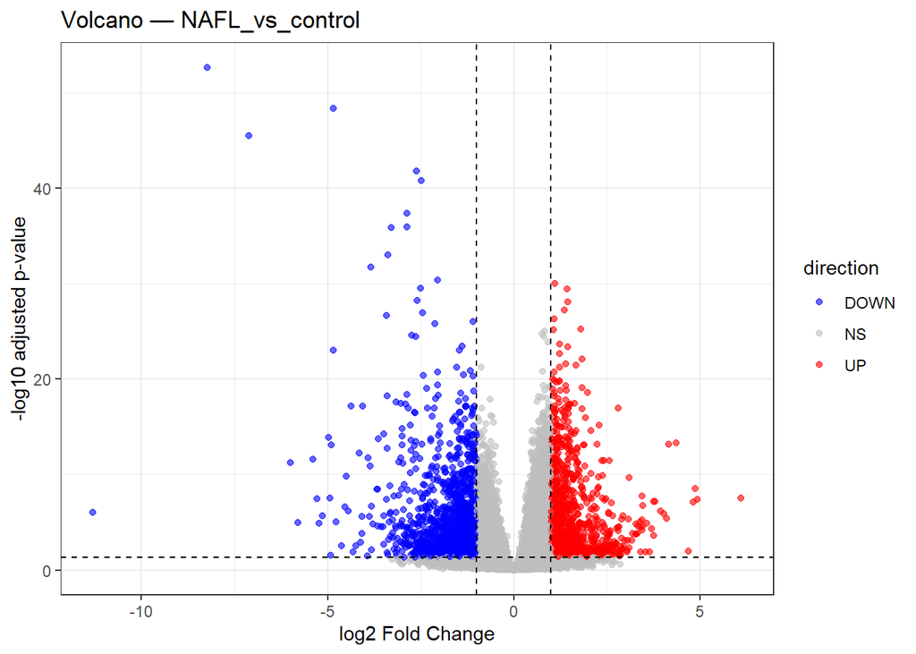

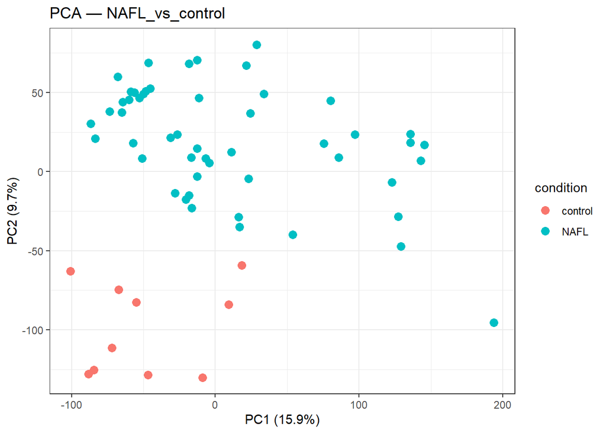

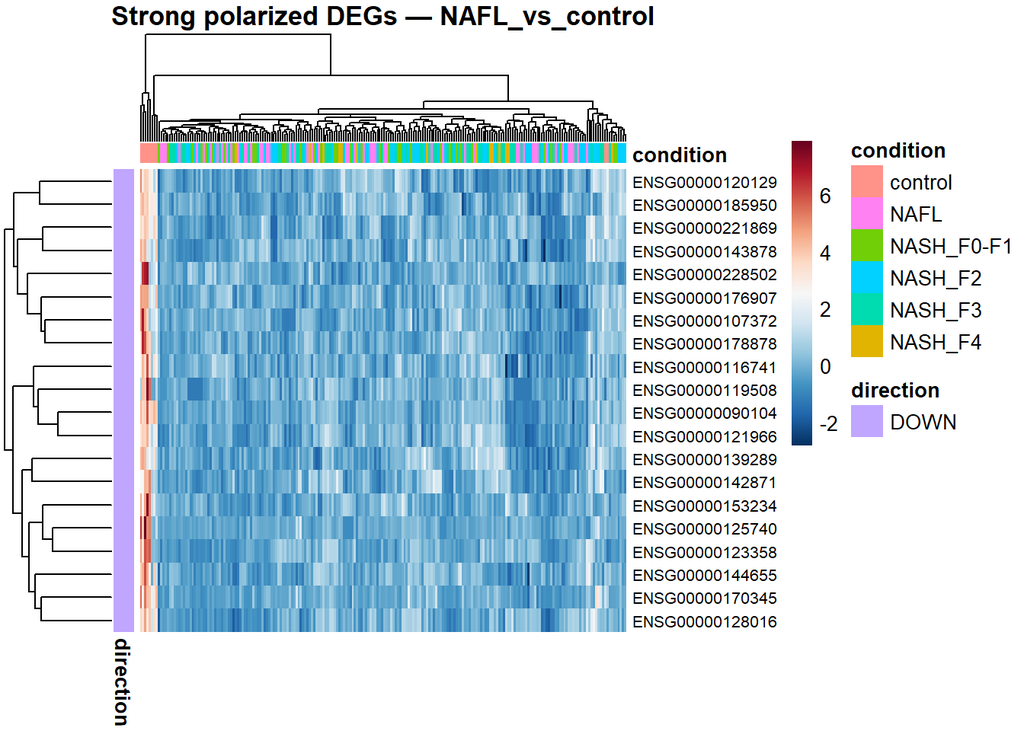

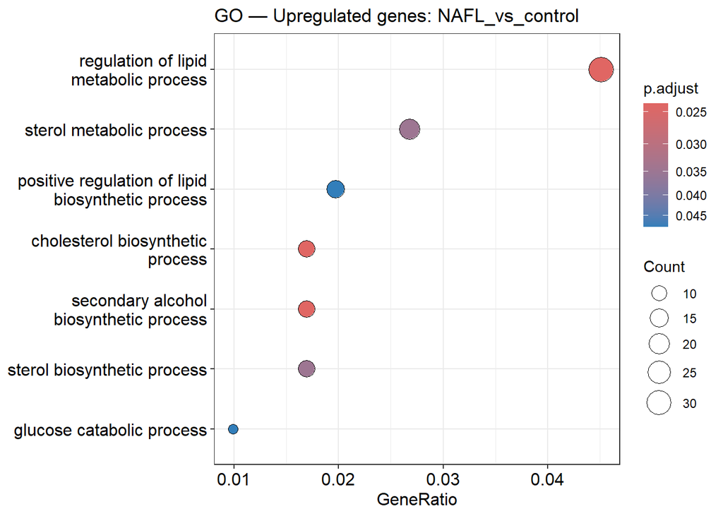

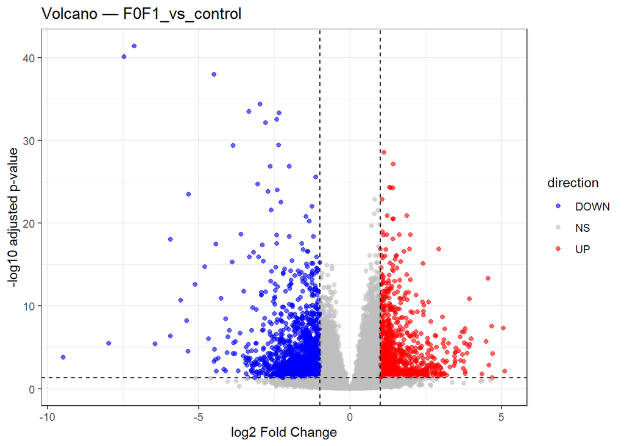

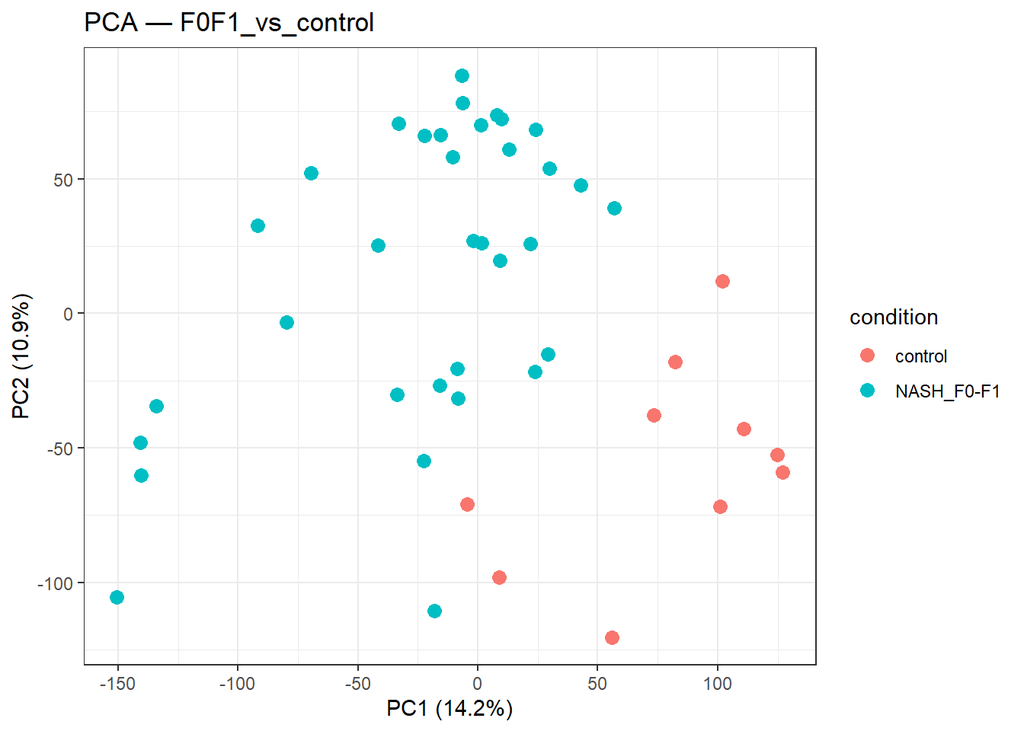

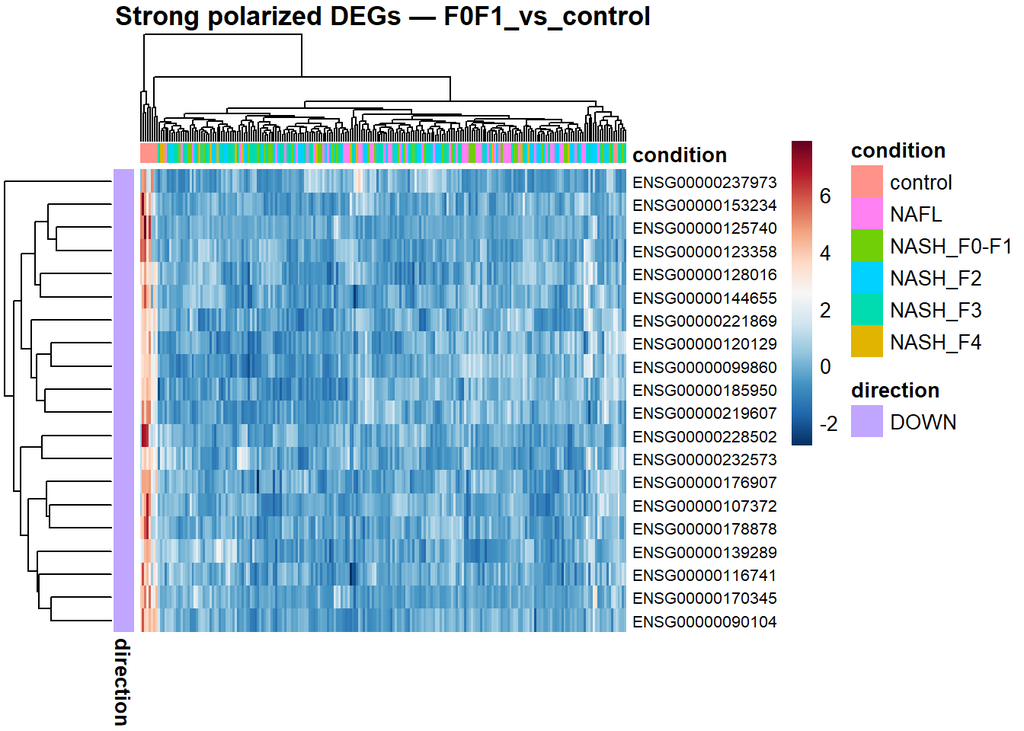

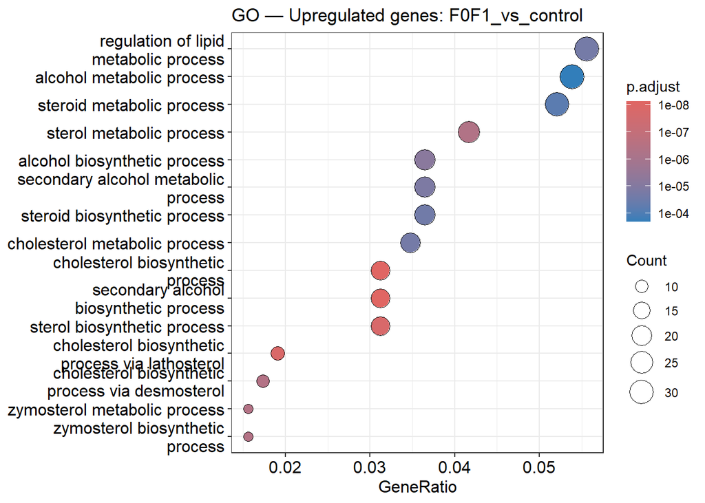

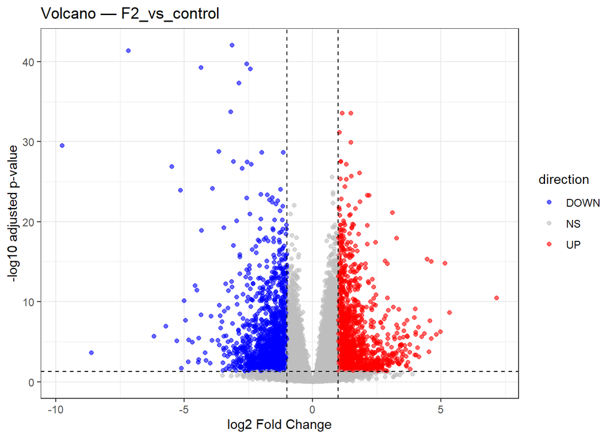

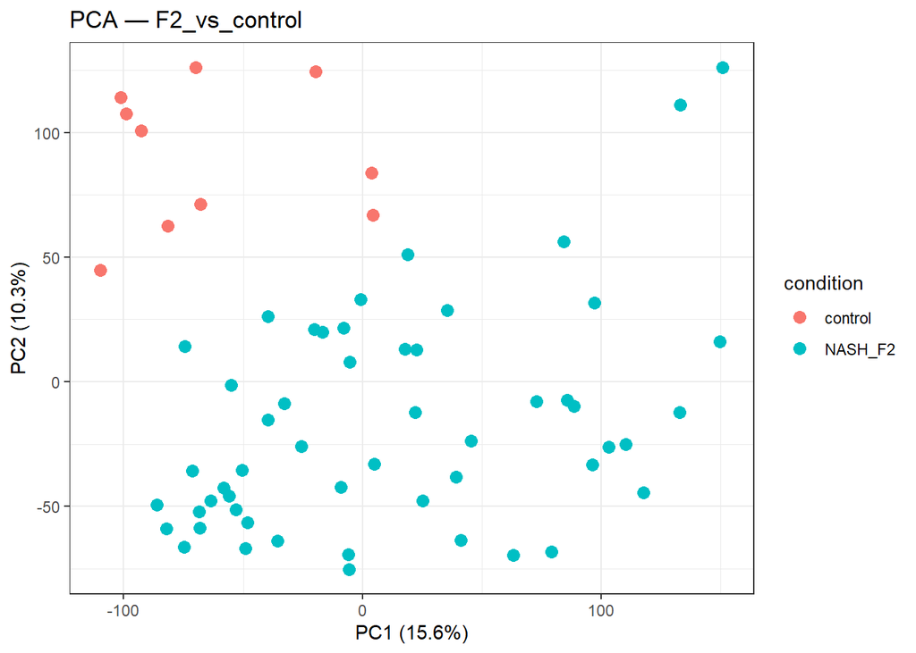

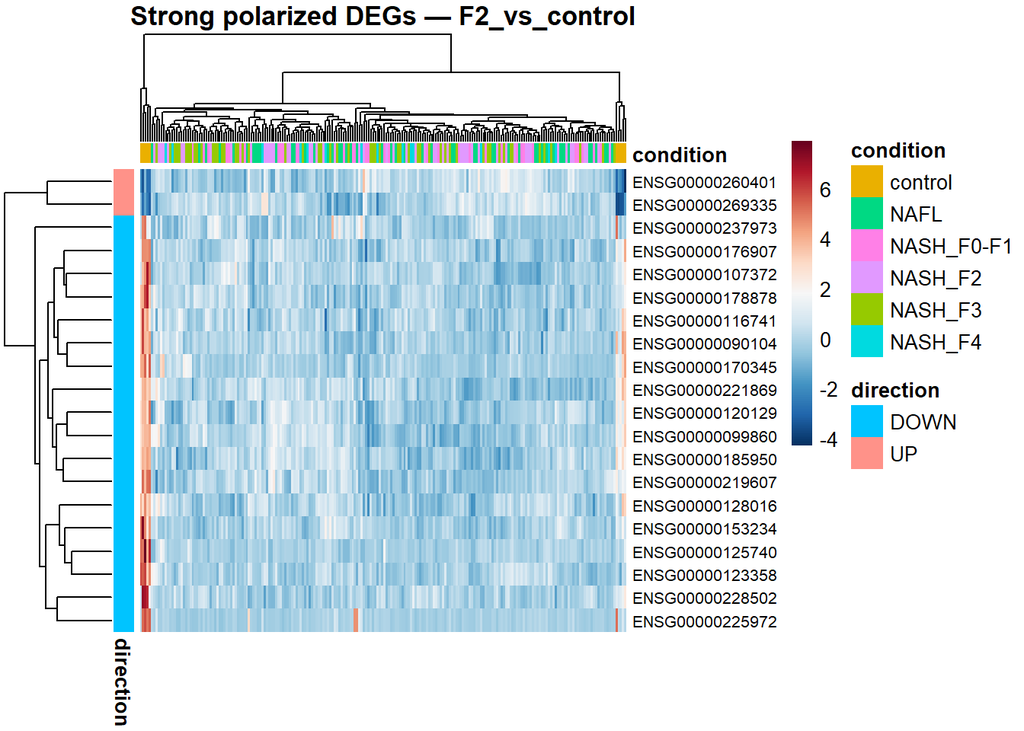

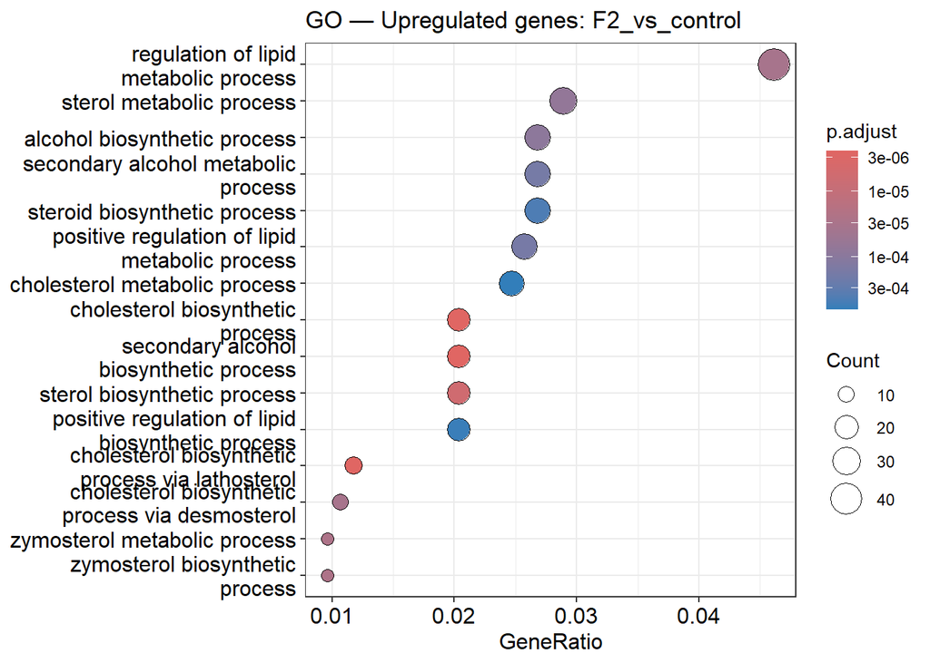

[8 more figures not shown]

[output not shown]

[output cut: 65 more lines]

```
##
## **PCA interpretation — F4_vs_control **
## - PC1 explains: 19.2 % of variance
## - PC2 explains: 11.3 % of variance
## → Moderate structure: partial separation.
## → Visual separation on the PCA plot indicates biological divergence.
##
## **Heatmap interpretation — F4_vs_control **
## → Strong polarized signature: clear up/down blocks visible.
## → Red = upregulated, Blue = downregulated.
## → Clear block structure indicates coherent biological programs.
##
## **GO interpretation — F4_vs_control **
## → Enriched GO terms highlight the dominant biological processes.
## → Typically immune activation, ECM remodeling, or metabolic pathways in NAFLD.
```

```r
# ---- run_pipeline ----

annotated_results <- list()

for (name in names(all_results)) {

  cat("\n\n===== Processing:", name, "=====\n\n")

  # 1. Annoter
  res_ann <- annotate_results(all_results[[name]])
  annotated_results[[name]] <- res_ann


  # ============================================================
  # 2. VOLCANO + INTERPRÉTATION
  # ============================================================

  print(plot_volcano(res_ann, name))

  up_count   <- sum(res_ann$direction == "UP",   na.rm = TRUE)
  down_count <- sum(res_ann$direction == "DOWN", na.rm = TRUE)

  cat("\n**Volcano interpretation —", name, "**\n")
  cat("- Upregulated genes:", up_count, "\n")
  cat("- Downregulated genes:", down_count, "\n")

  if ((up_count + down_count) < 50) {
    cat("→ Weak differential expression signal.\n")
  } else if (up_count > down_count) {
    cat("→ Upregulation dominates.\n")
  } else {
    cat("→ Downregulation dominates.\n")
  }



  # ============================================================
  # 3. PCA + INTERPRÉTATION
  # ============================================================

  # ---- PCA block inside run_pipeline ----

  groups <- contrast_list[[name]][2:3]
  pca_out <- plot_pca_contrast(vst_data, meta_aligned, groups[1], groups[2], name)

  # Affichage du plot PCA
  print(pca_out$plot)

  # Interprétation PCA
  cat("\n**PCA interpretation —", name, "**\n")

  if (is.null(pca_out$pca)) {

    cat("→ PCA could not be computed (insufficient variance).\n")

  } else {

    pc1 <- pca_out$percentVar[1]
    pc2 <- pca_out$percentVar[2]

    cat("- PC1 explains:", pc1, "% of variance\n")
    cat("- PC2 explains:", pc2, "% of variance\n")

    if (pc1 < 10) {
      cat("→ Very weak structure: groups likely overlap.\n")
    } else if (pc1 < 20) {
      cat("→ Moderate structure: partial separation.\n")
    } else {
      cat("→ Strong structure: clear separation likely.\n")
    }

    cat("→ Visual separation on the PCA plot indicates biological divergence.\n")
  }




  # ============================================================
  # 4. HEATMAP + INTERPRÉTATION
  # ============================================================

  plot_heatmap(res_ann, vst_data, meta_aligned, name)

  strong_genes_n <- sum(res_ann$padj < 0.01 & abs(res_ann$log2FoldChange) >= 2, na.rm = TRUE)

  cat("\n**Heatmap interpretation —", name, "**\n")

  if (strong_genes_n < 10) {
    cat("→ Few strongly polarized genes: weak transcriptional signature.\n")
  } else if (strong_genes_n < 50) {
    cat("→ Moderate number of polarized genes: interpretable patterns.\n")
  } else {
    cat("→ Strong polarized signature: clear up/down blocks visible.\n")
  }

  cat("→ Red = upregulated, Blue = downregulated.\n")
  cat("→ Clear block structure indicates coherent biological programs.\n")



  # ============================================================
  # 5. GO + INTERPRÉTATION
  # ============================================================

  go_plot <- run_go(res_ann, name)
  print(go_plot)

  cat("\n**GO interpretation —", name, "**\n")
  cat("→ Enriched GO terms highlight the dominant biological processes.\n")
  cat("→ Typically immune activation, ECM remodeling, or metabolic pathways in NAFLD.\n")
}
```

### 9.7 9.8 Summary table of all contrasts

A concise table summarizing the number of up‑ and down‑regulated genes for each contrast.

```r
# ---- summary_all ----

library(knitr)
library(kableExtra)

summary_df <- data.frame(
  Contrast  = names(annotated_results),
  Up_DEGs   = sapply(annotated_results, function(x) sum(x$direction == "UP")),
  Down_DEGs = sapply(annotated_results, function(x) sum(x$direction == "DOWN"))
)

kable(summary_df, format="html", caption="Summary of all contrasts") %>%
  kable_styling(full_width=FALSE, bootstrap_options=c("striped","hover"))
```

Summary of all contrasts

|  | Contrast | Up_DEGs | Down_DEGs |
| --- | --- | --- | --- |
| NAFL_vs_control | NAFL_vs_control | 1102 | 1838 |
| F0F1_vs_control | F0F1_vs_control | 923 | 1711 |
| F2_vs_control | F2_vs_control | 1383 | 1836 |
| F3_vs_control | F3_vs_control | 1281 | 1454 |
| F4_vs_control | F4_vs_control | 1756 | 1346 |

### 9.8 9.9 Summary barplot of DEGs per contrast

A stacked barplot visualizing the distribution of DEGs across contrasts.

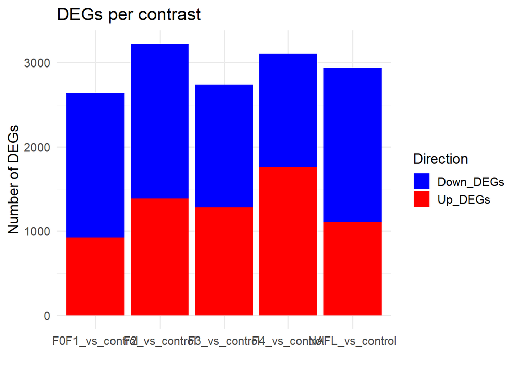

```r
# ---- summary_barplot ----

library(ggplot2)
library(tidyr)

summary_long <- summary_df |>
  pivot_longer(cols = c("Up_DEGs", "Down_DEGs"),
               names_to = "Direction", values_to = "Count")

ggplot(summary_long, aes(x = Contrast, y = Count, fill = Direction)) +
  geom_bar(stat="identity", position="stack") +
  scale_fill_manual(values=c(Up_DEGs="red", Down_DEGs="blue")) +
  theme_minimal(base_size=14) +
  labs(title="DEGs per contrast", y="Number of DEGs", x="")
```